# Music Taste Analysis

Ever been asked what sort of music you like and felt unable to describe it convincingly? This notebook represents my effort to once and for all answer the question, because, yes, I regard it to be this complicated.

### How to Use

My first pass at this depended upon [Watsonbox's Exportify](https://github.com/watsonbox/exportify), but I decided I didn't like his version because of bugs and inadequate output detail. So I [went and forked it](https://github.com/pavelkomarov/exportify), cleaned up [the](https://github.com/pavelkomarov/exportify/blob/master/index.html) [code](https://github.com/pavelkomarov/exportify/blob/master/exportify.js), and [hosted it](https://exportify.net) myself.

As such, the code here depends on `.csv` inputs in the format output by [my version](https://exportify.net).

1. To get started, hop on over there, sign in to Spotify to give the app access to your playlists, and export whatever you like.
2. Next, either download this `.ipynb` file and run the notebook yourself or [launch it in Binder](https://mybinder.org/v2/gh/pavelkomarov/exportify/master).
3. Either put the downloaded `.csv` in the same directory as the notebook, or upload it in Binder.
4. Open the `.ipynb` through your browser, update the `filename` variable in the first code cell to point to your playlist instead, and `shift+enter` in each following code cell to generate the corresponding plot. (Or select `Cell` -> `Run All` from the menu to make all graphs at once.)

### Who Contributed?

Click name to get their playlist: [Otis](https://open.spotify.com/playlist/7BsyusbKhash4Wd0DjuWfs?si=Vc-WOgn7QVyN4SIaONLfmw) [Dante](https://open.spotify.com/playlist/6vo2PxzKpocfoFTeHlOLl6?si=cSTItVTnSu6DVkmq0T_SDw) [Quinn](https://open.spotify.com/playlist/1L8CkMb1RW5bAC2I9990h8?si=NS7b7V-9Q4-gunay6L0czA) [Nick](https://open.spotify.com/playlist/3C94DAtDguzKovLgsU3jGs?si=KnJrj2pSSc-ue2z453L2rw) [Tara](https://open.spotify.com/playlist/2k2JzkeZMbwH6doqjp1rTq?si=ZnMNohnxRZq5PctMdy0zgg) [Damian](https://open.spotify.com/playlist/22Iek9S4qQb2harEyex3tD?si=G-ziEi3YRKOtx1OiTok1pQ) [Liam](https://open.spotify.com/playlist/75FDbtImvgkazsNkQSfZar?si=CzHu7p7qSNyYhW83SOtZYw) [Zach](https://open.spotify.com/playlist/5VzmczwMtKwOYqQCefBCIh?si=UJB_8hSgSViX-YEPCg-7xw) [Brandon](https://open.spotify.com/playlist/556oyy2CFJRG6gQ8AkuflU?si=JnJ2h3cUTPm5Bi4yYQ3dMw)

### Read the Data

```python
filename = 'TopDecadeSongs.csv'

from matplotlib import pyplot
import seaborn
import pandas
from collections import defaultdict
from scipy.stats import pareto, gamma
from datetime import date
import os
os.chdir("C:\\Users\\Otis\\Documents\\Python Scripts\\Spotify")

# read the data
data = pandas.read_csv(filename,encoding = "ISO-8859-1")
print("total songs:", data.shape[0])
#print(data[:3])
```

```
total songs: 360
```

### Artist Bar Chart

Number of songs binned by artist.

```python
# count songs per artist
artists = defaultdict(int)
for i,song in data.iterrows():
	for musician in song['Artist Name(s)'].split(','):
		artists[musician] += 1

# sort for chart
artists = pandas.DataFrame(artists.items(), columns=['Artist', 'Num Songs']
                          ).sort_values('Num Songs', ascending=False).reset_index(drop=True)
print("number of unique artists:", artists.shape[0])
```

```
number of unique artists: 301
```

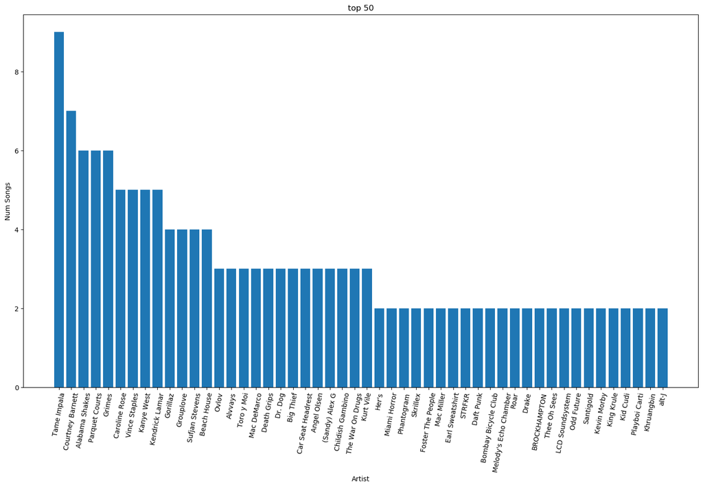

```python
pyplot.figure(figsize=(18, 10))
pyplot.bar(artists['Artist'][:50], artists['Num Songs'][:50])
pyplot.xticks(rotation=80)
pyplot.xlabel(artists.columns[0])
pyplot.ylabel(artists.columns[1])
pyplot.title('top 50');
```

### Top Tracks

```python
print("number of unique tracks:",data['Track Name'].nunique())
```

```
number of unique tracks: 317
```

```python
data['Song Count'] = data.groupby(['Artist Name(s)', 'Track Name'])["Album Name"].transform("count")
Track_Count = data[['Artist Name(s)', 'Track Name', 'Song Count']].sort_values('Song Count', ascending=False)
Track_Count = Track_Count.drop_duplicates('Track Name')
Track_Count = Track_Count.where(Track_Count['Song Count'] > 1)
Track_Count = Track_Count.dropna()
```

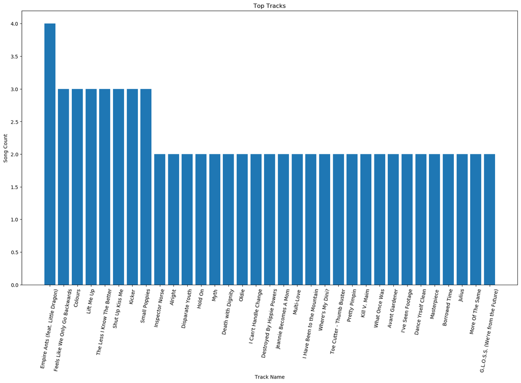

```python
pyplot.figure(figsize=(18, 10))
pyplot.bar(Track_Count['Track Name'][:50], Track_Count['Song Count'][:50])
pyplot.xticks(rotation=80)
pyplot.xlabel(Track_Count.columns[1])
pyplot.ylabel(Track_Count.columns[2])
pyplot.title('Top Tracks');
```

### Top Albums

```python
print("number of unique albums:",data['Album Name'].nunique())
```

```
number of unique albums: 287
```

```python
data['Album Count'] = data.groupby(['Artist Name(s)', 'Album Name'])["Track Name"].transform("count")
Album_Count = data[['Artist Name(s)', 'Album Name', 'Album Count']].sort_values('Album Count', ascending=False)
Album_Count = Album_Count.drop_duplicates('Album Name')
Album_Count = Album_Count.where(Album_Count['Album Count'] > 1)
Album_Count = Album_Count.dropna()
```

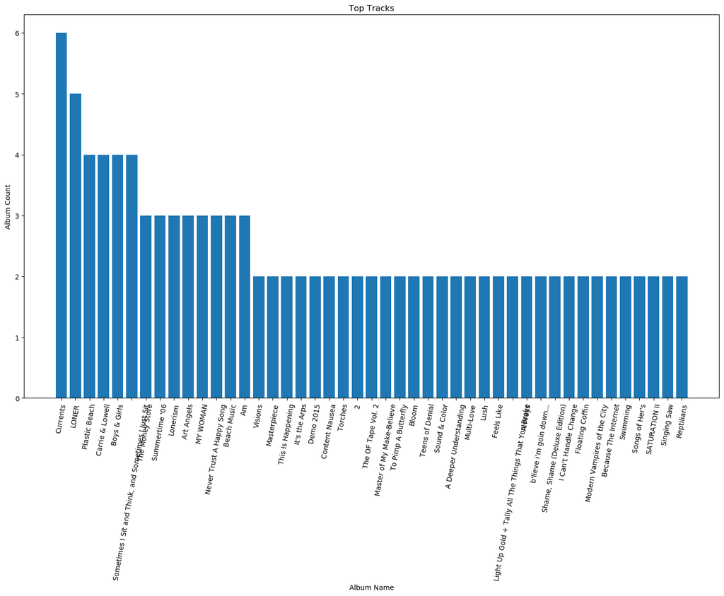

```python
pyplot.figure(figsize=(18, 10))
pyplot.bar(Album_Count['Album Name'][:50], Album_Count['Album Count'][:50])
pyplot.xticks(rotation=80)
pyplot.xlabel(Album_Count.columns[1])
pyplot.ylabel(Album_Count.columns[2])
pyplot.title('Top Tracks');
```

### Genres Bar Chart

Alright, enough messing around. All the above were possible with the output from Watsonbox's Exportify. Let's get to the novel stuff you came *here* for.

People describe music by genre. As we'll see, genre names are flippin' hilarious and extremely varied, but in theory if I cluster around a few, that should give you a flavor of my tastes.

```python
# count songs per genre
genres = defaultdict(int)
for i,song in data.iterrows():
    if type(song['Genres']) is str: # some times there aren't any, and this is NaN
        for genre in song['Genres'].split(','):
            if len(genre) > 0: # empty string seems to be a legit genre
                genres[genre] += 1

# sort for chart
genres = pandas.DataFrame(genres.items(), columns=['Genre', 'Num Songs']
                          ).sort_values('Num Songs', ascending=False).reset_index(drop=True)
print("number of unique genres:", genres.shape[0])
```

```
number of unique genres: 335
```

Let's look at the top 50 so we can read the names.

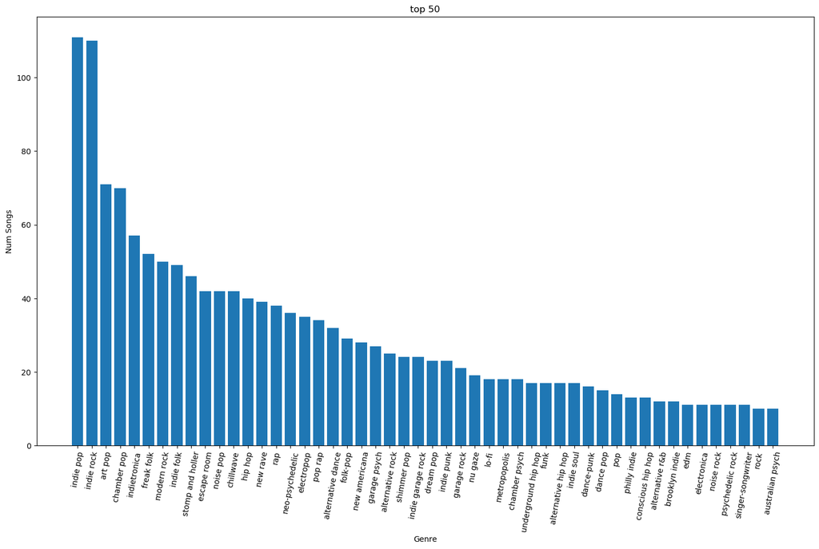

```python
pyplot.figure(figsize=(18, 10))
pyplot.bar(genres['Genre'][:50], genres['Num Songs'][:50])
pyplot.xticks(rotation=80)
pyplot.xlabel(genres.columns[0])
pyplot.ylabel(genres.columns[1])
pyplot.title('top 50');
```

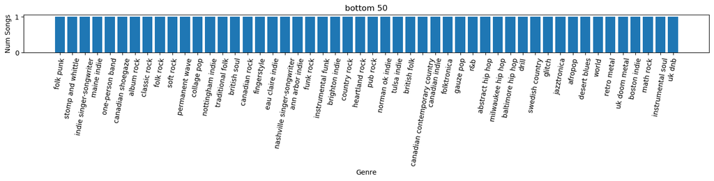

```python
pyplot.figure(figsize=(18, 1))
pyplot.bar(genres['Genre'][-50:], genres['Num Songs'][-50:])
pyplot.xticks(rotation=80)
pyplot.xlabel(genres.columns[0])
pyplot.ylabel(genres.columns[1])
pyplot.title('bottom 50');
```

### Release Dates

Which year was the most?

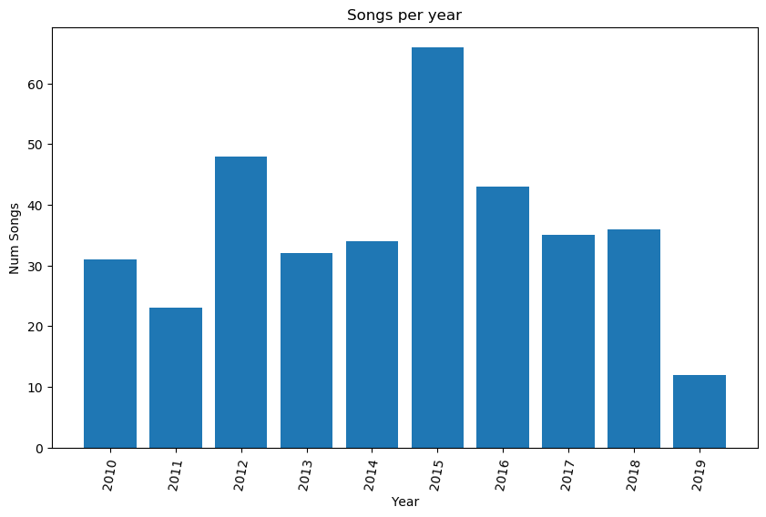

```python
years = defaultdict(int)
for i,song in data.iterrows():
    years[song['Release Date'][-4:]] += 1

years = pandas.DataFrame(years.items(), columns=['Year', 'Num Songs']
                          ).sort_values('Year')

pyplot.figure(figsize=(10, 6))
pyplot.bar(years['Year'], years['Num Songs'])
pyplot.xticks(rotation=80)
pyplot.xlabel(years.columns[0])
pyplot.ylabel(years.columns[1])
pyplot.title('Songs per year');
```

```python
data['Release Year'] = data['Release Date'].str[-4:]
```

```python
import pandas as pd
#yearcount = pd.DataFrame(data.groupby(['Playlist Creator','Release Year']).count()[['Track Name']])
yeardf = data.pivot_table(index='Playlist Creator', columns = 'Release Year',values = 'Track Name',aggfunc=len,fill_value=0)
yeardf
```

| Release Year Playlist Creator | 2010 | 2011 | 2012 | 2013 | 2014 | 2015 | 2016 | 2017 | 2018 | 2019 |
| --- | --- | --- | --- | --- | --- | --- | --- | --- | --- | --- |
| Brandon | 6 | 1 | 7 | 3 | 1 | 8 | 4 | 3 | 7 | 1 |
| Dad | 2 | 6 | 4 | 3 | 2 | 5 | 8 | 4 | 5 | 2 |
| Dante | 3 | 3 | 5 | 3 | 4 | 7 | 6 | 5 | 3 | 1 |
| Liam | 3 | 2 | 6 | 5 | 6 | 10 | 3 | 3 | 0 | 2 |
| Nick | 5 | 2 | 4 | 4 | 3 | 8 | 3 | 3 | 4 | 2 |
| Otis | 2 | 3 | 8 | 4 | 3 | 8 | 5 | 0 | 6 | 1 |
| Quinn | 4 | 2 | 4 | 1 | 5 | 7 | 8 | 7 | 1 | 1 |
| Tara | 5 | 3 | 6 | 3 | 2 | 7 | 4 | 4 | 5 | 1 |
| Zach | 1 | 1 | 4 | 6 | 8 | 6 | 2 | 6 | 5 | 1 |

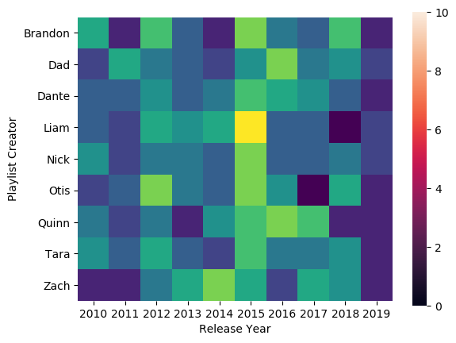

```python
import seaborn.apionly as sns
import matplotlib.pyplot as plt
ax = sns.heatmap(yeardf, square=True)
plt.pcolor(yeardf)
```

### Popularity Contest

This is my least favorite stat as I don't find it to be too accurate so I won't average it out for everyone. I wish you could pull direct plays from spotify but for some reason you can't....

```
Average song popularity:  44.608108108108105
Median song popularity:  45.5
Max song popularity:  90
```

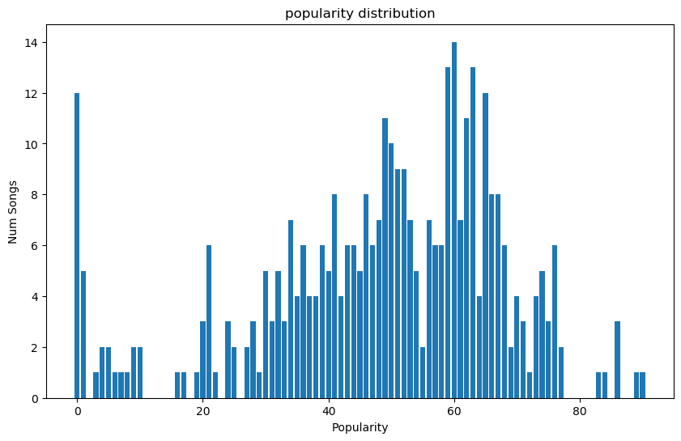

```python
popularity = defaultdict(int)
for i,song in data.iterrows():
    popularity[song['Popularity']] += 1

popularity = pandas.DataFrame(popularity.items(), columns=['Popularity', 'Num Songs']
                          ).sort_values('Popularity')

pyplot.figure(figsize=(10, 6))
pyplot.bar(popularity['Popularity'].values, popularity['Num Songs'].values)
pyplot.xlabel(popularity.columns[0])
pyplot.ylabel(popularity.columns[1])
pyplot.title('popularity distribution');

print("Average song popularity: ", popularity['Popularity'].mean())
print("Median song popularity: ", popularity['Popularity'].median())
print("Max song popularity: ", popularity['Popularity'].max())
```

### Track Duration

Do we prefer long songs or short ones?

```
Average song length: 4:30.006102777777755
Median song length: 4:01.3085000000000093
```

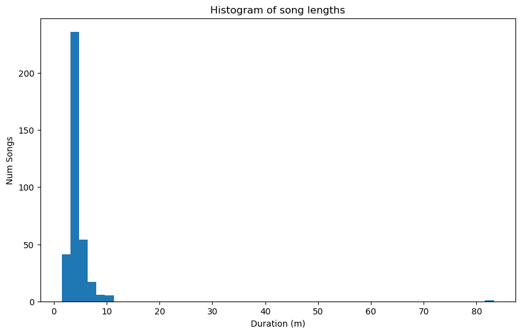

```python
pyplot.figure(figsize=(10,6))
pyplot.hist(data['Duration (ms)']/1000/60, bins=50);
pyplot.xlabel('Duration (m)')
pyplot.ylabel('Num Songs')
pyplot.title('Histogram of song lengths')

mean = data['Duration (ms)'].mean()/1000
median = data['Duration (ms)'].median()/1000
print("Average song length: " + str(int(mean//60)) + (":" if mean%60 >=10 else ":0")
      + str(mean%60))
print("Median song length: " + str(int(median//60)) + (":" if median%60 >=10 else ":0")
      + str(median%60))
```

Median is lower than the mean, so I'm skewed right. That is, we have some long songs. What are they?

```python
print("Longest Hall of Fame:")
print(data[['Playlist Creator','Track Name', 'Artist Name(s)', 'Release Date', 'Duration (ms)']].sort_values(
    'Duration (ms)', ascending=False)[:10])
```

```
Longest Hall of Fame:
    Playlist Creator                                    Track Name  \
344          Brandon                                 Mirror Reaper
271              Dad                        Keep On Growing - Live
104            Dante                                         Oldie
140             Zach                                         Oldie
326          Brandon                                     Sunbather
319          Brandon  Death to the King and All His Loyal Subjects
150             Zach                         Wakin on a Pretty Day
325          Brandon                                   Washerwoman
159             Liam                            Dance Yrself Clean
118             Zach                            Dance Yrself Clean

           Artist Name(s) Release Date  Duration (ms)
344            Bell Witch   10/20/2017        4995314
271  Tedeschi Trucks Band    3/17/2017         650746
104            Odd Future    3/16/2012         636213
140            Odd Future    3/16/2012         636213
326            Deafheaven    5/28/2013         616786
319           Ragana,Thou    9/25/2018         602643
150             Kurt Vile     4/8/2013         570733
325         Bosse-de-Nage    4/14/2015         561840
159       LCD Soundsystem    5/17/2010         536471
118       LCD Soundsystem    5/17/2010         536471
```

### How we breakdown indivudually on Audio Features

Spotify has a lot of interesting audio features for tracks, a lot of the features aren't self explanatory so I'll share the definitions below:

**Tempo** - The overall estimated tempo of a track in beats per minute (BPM). In musical terminology, tempo is the speed or pace of a given piece and derives directly from the average beat duration.

**Acousticness** - A confidence measure from 0.0 to 1.0 of whether the track is acoustic. 1.0 represents high confidence the track is acoustic.

**Instrumentalness** - Predicts whether a track contains no vocals. “Ooh” and “aah” sounds are treated as instrumental in this context. Rap or spoken word tracks are clearly “vocal”. The closer the instrumentalness value is to 1.0, the greater likelihood the track contains no vocal content. Values above 0.5 are intended to represent instrumental tracks, but confidence is higher as the value approaches 1.0.

**Liveness** - Detects the presence of an audience in the recording. Higher liveness values represent an increased probability that the track was performed live. A value above 0.8 provides strong likelihood that the track is live.

**Valence** - A measure from 0.0 to 1.0 describing the musical positiveness conveyed by a track. Tracks with high valence sound more positive (e.g. happy, cheerful, euphoric), while tracks with low valence sound more negative (e.g. sad, depressed, angry)

**Spechiness** - Speechiness detects the presence of spoken words in a track. The more exclusively speech-like the recording (e.g. talk show, audio book, poetry), the closer to 1.0 the attribute value. Values above 0.66 describe tracks that are probably made entirely of spoken words. Values between 0.33 and 0.66 describe tracks that may contain both music and speech, either in sections or layered, including such cases as rap music. Values below 0.33 most likely represent music and other non-speech-like tracks.

**Loudness** - The overall loudness of a track in decibels (dB). Loudness values are averaged across the entire track and are useful for comparing relative loudness of tracks. Loudness is the quality of a sound that is the primary psychological correlate of physical strength (amplitude). Values typical range between -60 and 0 db.

**Energy** - Energy is a measure from 0.0 to 1.0 and represents a perceptual measure of intensity and activity. Typically, energetic tracks feel fast, loud, and noisy. For example, death metal has high energy, while a Bach prelude scores low on the scale. Perceptual features contributing to this attribute include dynamic range, perceived loudness, timbre, onset rate, and general entropy.

**Danceability** - Danceability describes how suitable a track is for dancing based on a combination of musical elements including tempo, rhythm stability, beat strength, and overall regularity. A value of 0.0 is least danceable and 1.0 is most danceable.

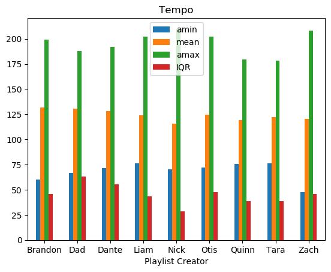

```
                    amin        mean     amax       IQR
Playlist Creator
Brandon           60.061  131.699976  199.311  45.98300
Dad               66.423  130.324659  187.804  62.91900
Dante             71.258  128.257900  192.281  55.22925
Otis              72.044  124.824825  201.956  47.60250
Liam              76.270  123.944975  202.032  43.67800
Tara              76.538  122.284625  178.531  38.44550
Zach              47.811  120.539900  207.969  45.68075
Quinn             75.535  119.173250  179.810  38.34500
Nick              70.048  115.573711  210.145  28.37900
```

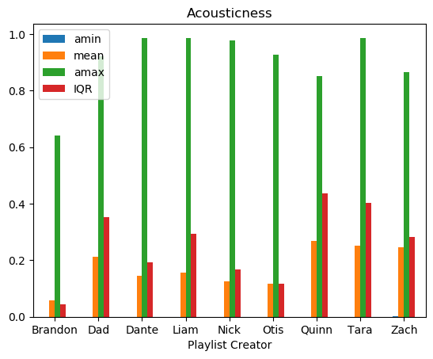

```
                      amin      mean   amax       IQR
Playlist Creator
Quinn             0.000038  0.268439  0.852  0.437525
Tara              0.000115  0.251310  0.986  0.402275
Zach              0.001310  0.246815  0.866  0.281775
Dad               0.000047  0.213352  0.921  0.353100
Liam              0.000007  0.156999  0.986  0.293288
Dante             0.000200  0.145051  0.987  0.193975
Nick              0.000333  0.125929  0.979  0.166985
Otis              0.000034  0.116364  0.927  0.116145
Brandon           0.000001  0.056772  0.641  0.044438
```

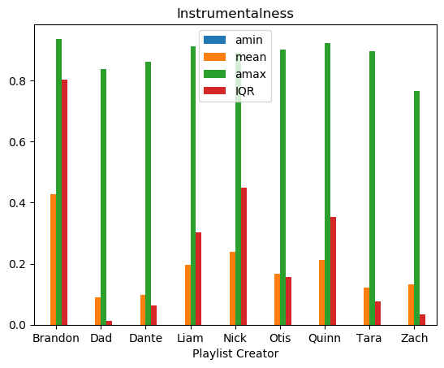

```
                      amin      mean   amax       IQR
Playlist Creator
Brandon           0.000000  0.429114  0.937  0.803310
Nick              0.000002  0.238460  0.892  0.449300
Quinn             0.000000  0.212280  0.924  0.351981
Liam              0.000000  0.197009  0.912  0.301807
Otis              0.000000  0.165824  0.901  0.156884
Zach              0.000000  0.131252  0.766  0.034069
Tara              0.000000  0.122714  0.897  0.075858
Dante             0.000000  0.098633  0.863  0.062950
Dad               0.000000  0.089313  0.838  0.012775
```

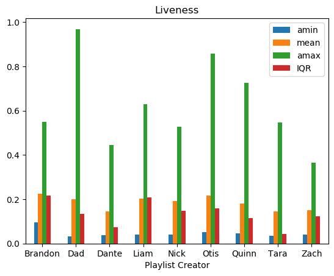

```
                    amin      mean   amax       IQR
Playlist Creator
Brandon           0.0942  0.224417  0.549  0.216000
Otis              0.0509  0.217198  0.857  0.158325
Liam              0.0400  0.201713  0.628  0.209300
Dad               0.0317  0.200232  0.968  0.134300
Nick              0.0398  0.190439  0.528  0.148500
Quinn             0.0453  0.181910  0.724  0.114050
Zach              0.0400  0.149533  0.366  0.123025
Tara              0.0353  0.145313  0.546  0.044150
Dante             0.0368  0.145272  0.444  0.074100
```

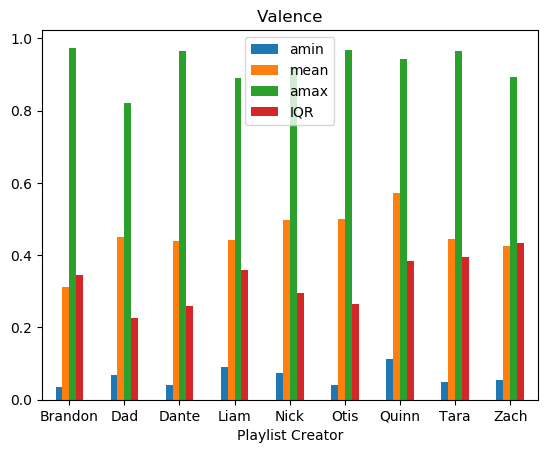

```
                    amin      mean   amax      IQR
Playlist Creator
Quinn             0.1130  0.572625  0.944  0.38250
Otis              0.0397  0.499968  0.967  0.26475
Nick              0.0747  0.498016  0.922  0.29550
Dad               0.0677  0.449139  0.821  0.22700
Tara              0.0495  0.445232  0.964  0.39425
Liam              0.0900  0.442110  0.890  0.35950
Dante             0.0394  0.440135  0.965  0.25825
Zach              0.0552  0.424582  0.894  0.43500
Brandon           0.0353  0.311583  0.974  0.34600
```

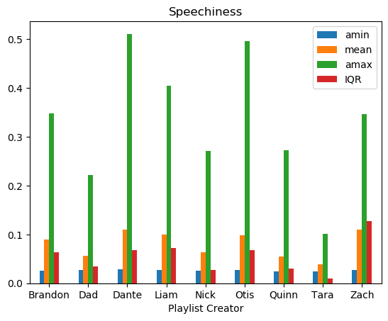

```
                    amin      mean   amax       IQR
Playlist Creator
Dante             0.0284  0.110310  0.511  0.067650
Zach              0.0269  0.109483  0.347  0.128050
Liam              0.0278  0.099337  0.405  0.071700
Otis              0.0265  0.098458  0.496  0.067850
Brandon           0.0259  0.089246  0.348  0.063900
Nick              0.0257  0.063129  0.271  0.027525
Dad               0.0269  0.056627  0.222  0.034700
Quinn             0.0238  0.054215  0.273  0.029725
Tara              0.0242  0.038560  0.101  0.010075
```

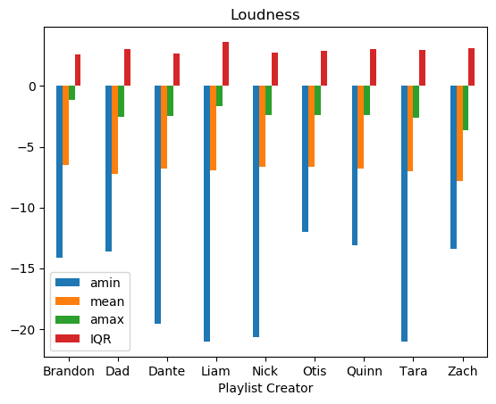

```
                    amin      mean   amax      IQR
Playlist Creator
Brandon          -14.110 -6.517293 -1.162  2.61400
Nick             -20.700 -6.649500 -2.352  2.72025
Otis             -11.973 -6.669100 -2.352  2.88375
Dante            -19.581 -6.791675 -2.431  2.70425
Quinn            -13.088 -6.805375 -2.352  3.03475
Liam             -21.030 -6.976000 -1.672  3.63750
Tara             -21.030 -7.020600 -2.626  2.94250
Dad              -13.631 -7.200732 -2.500  3.03900
Zach             -13.424 -7.849675 -3.626  3.08875
```

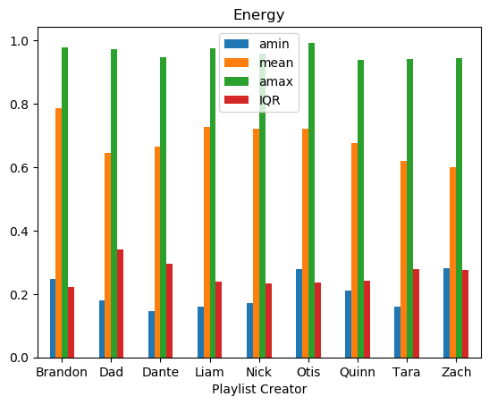

```
                   amin      mean   amax      IQR
Playlist Creator
Brandon           0.248  0.786268  0.977  0.22300
Liam              0.160  0.726150  0.976  0.24025
Nick              0.172  0.721842  0.959  0.23475
Otis              0.278  0.720425  0.993  0.23725
Quinn             0.211  0.676650  0.939  0.24275
Dante             0.145  0.665000  0.947  0.29600
Dad               0.179  0.645171  0.973  0.34100
Tara              0.160  0.620625  0.942  0.27725
Zach              0.282  0.599225  0.944  0.27700
```

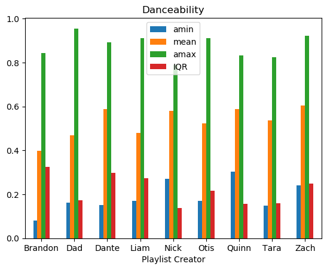

```
                    amin      mean   amax      IQR
Playlist Creator
Zach              0.2410  0.605400  0.921  0.24925
Dante             0.1500  0.588600  0.891  0.29825
Quinn             0.3030  0.586825  0.831  0.15750
Nick              0.2700  0.579737  0.790  0.13650
Tara              0.1480  0.535475  0.823  0.16050
Otis              0.1700  0.523200  0.912  0.21625
Liam              0.1700  0.478775  0.912  0.27375
Dad               0.1620  0.469220  0.955  0.17200
Brandon           0.0804  0.396759  0.844  0.32400
```

```python
import numpy as np
statsdf = pd.DataFrame(data[['Playlist Creator','Tempo', 'Acousticness', 'Instrumentalness', 'Liveness',
                            'Valence', 'Speechiness', 'Loudness', 'Energy', 'Danceability']])
statsgroup = statsdf.groupby(['Playlist Creator'])
def IQR(x):
    IQR=np.percentile(x,75) - np.percentile(x,25)
    return IQR
statstest = statsgroup.agg([np.min,np.mean,np.max, IQR])


statstest['Tempo'].plot.bar(rot=0, title='Tempo')
plt.show()
print(statstest['Tempo'].sort_values(by=['mean'], ascending=False))
statstest['Acousticness'].plot.bar(rot=0, title='Acousticness')
plt.show()
print(statstest['Acousticness'].sort_values(by=['mean'], ascending=False))
statstest['Instrumentalness'].plot.bar(rot=0, title='Instrumentalness')
plt.show()
print(statstest['Instrumentalness'].sort_values(by=['mean'], ascending=False))
statstest['Liveness'].plot.bar(rot=0, title='Liveness')
plt.show()
print(statstest['Liveness'].sort_values(by=['mean'], ascending=False))
statstest['Valence'].plot.bar(rot=0, title='Valence')
plt.show()
print(statstest['Valence'].sort_values(by=['mean'], ascending=False))
statstest['Speechiness'].plot.bar(rot=0, title='Speechiness')
plt.show()
print(statstest['Speechiness'].sort_values(by=['mean'], ascending=False))
statstest['Loudness'].plot.bar(rot=0, title='Loudness')
plt.show()
print(statstest['Loudness'].sort_values(by=['mean'], ascending=False))
statstest['Energy'].plot.bar(rot=0, title='Energy')
plt.show()
print(statstest['Energy'].sort_values(by=['mean'], ascending=False))
statstest['Danceability'].plot.bar(rot=0, title='Danceability')
plt.show()
print(statstest['Danceability'].sort_values(by=['mean'], ascending=False))
```

### How we compare to all of spotify users as a group

In the interest of understanding user tastes and providing the best possible music recommendations, Spotify has done [some really sophisticated analysis](http://benanne.github.io/2014/08/05/spotify-cnns.html) of actual track content. Music is a time series, but most similarity metrics (and most ML methods generally) require inputs to be vectors, that is: points in some feature-space. So they've transformed the tracks to numerical metrics like Energy and Valence (continuous) and Key (discrete).

For the continuous metrics, they [provide distributions across all music](https://developer.spotify.com/documentation/web-api/reference/tracks/get-audio-features/). Here they are next to similar plots of our songs.

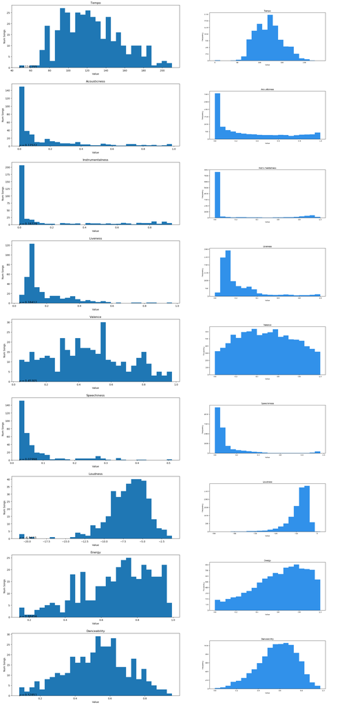

```python
pyplot.figure(figsize=(20,40))

for i,category in enumerate(['Tempo', 'Acousticness', 'Instrumentalness', 'Liveness',
                            'Valence', 'Speechiness', 'Loudness', 'Energy', 'Danceability']):
    pyplot.subplot(9, 2, i*2+1)
    # It would be nice to show the KDE on these plots, but there isn't a way
    # to show it on unnormalized https://github.com/mwaskom/seaborn/issues/479
    pyplot.hist(data[category], bins=30)
    pyplot.text(min(data[category]), 0, r'$\mu=$'+str(data[category].mean())[:7], fontsize=12)
    pyplot.xlabel('Value')
    pyplot.ylabel('Num Songs')
    pyplot.title(category)

    pyplot.subplot(9, 2, i*2+2)
    pyplot.imshow(pyplot.imread('https://developer.spotify.com/assets/audio/'+
                                category.lower()+'.png'))
    pyplot.axis('off')

pyplot.tight_layout(h_pad=2)
```

### Time Signature, Key, Major vs Minor Key

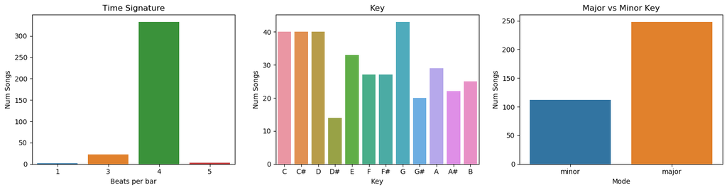

```python
pyplot.figure(figsize=(15,4))

pyplot.subplot(1, 3, 1)
seaborn.countplot(data['Time Signature'])
pyplot.xlabel('Beats per bar')
pyplot.ylabel('Num Songs')
pyplot.title('Time Signature')

pyplot.subplot(1, 3, 2)
axes = seaborn.countplot(data['Key'])
axes.set(xticklabels=['C', 'C#', 'D', 'D#', 'E', 'F', 'F#', 'G', 'G#', 'A', 'A#', 'B'])
pyplot.ylabel('Num Songs')
pyplot.title('Key')

pyplot.subplot(1, 3, 3)
axes = seaborn.countplot(data['Mode'])
axes.set(xticklabels=['minor', 'major'])
pyplot.ylabel('Num Songs')
pyplot.title('Major vs Minor Key');

pyplot.tight_layout(w_pad=2)
```

```python
#print('5:\n', data.loc[data['Time Signature']==5][
 #   ['Track Name', 'Artist Name(s)', 'Release Date']][:20])
```

```python
#print('0:\n', data.loc[data['Time Signature']==0][
#    ['Track Name', 'Artist Name(s)', 'Release Date']][:10])
#print('\n1:\n', data.loc[data['Time Signature']==1][
#    ['Track Name', 'Artist Name(s)', 'Release Date']][:20])
```